# simple data visualization

LoveA

2022-07-25

```
                       My First Data Visualization
```

let’s load some libraries

```r
library(tidyverse) # helps us to interact with data
library(gapminder) # Gives us access to the dataset "gapminder"
library(patchwork) # Helps in data visualization
```

```r
data() # shows data stored in R
```

data: gapminder

- Question 1: What is the mean life expectancy in “Africa” ?

```r
View(gapminder) # to view the data set
```

N/B: we will be using %>% operator and some functions in our coding

- %>% => This is called ‘piped in operator’. It informs R about the data you want to bring into the next line of code.

```r
gapminder %>%
  filter(continent =="Africa") %>%  # used to filter out the particular population
  select(lifeExp, continent) %>%    # select() used to select the variable
  summarise(mean = mean(lifeExp))   # summarise() used to summarise result
```

```
## # A tibble: 1 x 1
##    mean
##   <dbl>
## 1  48.9
```

Answer: The mean life expectancy in Africa is 48.9yrs

The mean life expectancy can also be calculated using Pull()

```r
gapminder %>%
  filter(continent =="Africa") %>%
  pull(lifeExp) %>%
  mean() %>%
  signif(4)     # helps to round up to 4 decimal point
```

```
## [1] 48.87
```

Data Visualization: Plot a density graph for the mean life Expectancy in Africa

before we include ggplot to our code, let’s assing the value of the mean life expectancy in Africa to a variable. that variable will be called “mean_x”

```r
mean_x <- gapminder %>%
  filter(continent =="Africa") %>%
  pull(lifeExp) %>%
  mean() %>%
  signif(4)
```

```r
View(mean_x) # view the variable
```

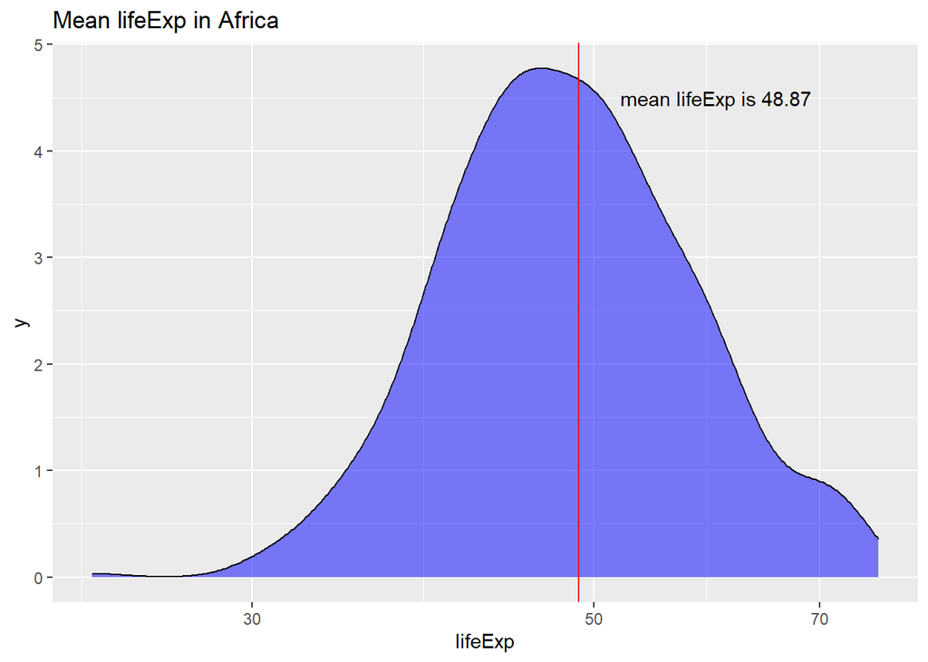

```r
gapminder %>%
  filter(continent =="Africa") %>%
  select(continent,lifeExp) %>%
  ggplot(aes(lifeExp))+
  geom_density(fill="blue", alpha = 0.5)+
  scale_x_log10()+
  geom_vline(xintercept = mean_x, color="red")+
  labs(title = "Mean lifeExp in Africa")+
  annotate("text", x=60, y=4.5, label ="mean lifeExp is 48.87")
```

- Question 2: calculate the mean life expectancy for all continent and plot a graph indicating point of each variances.

First of all; let’s calculate the mean lifeExp for the five continent

```r
 gapminder %>%
  select(continent, lifeExp) %>%
  group_by(continent) %>%
  summarise(mean =mean(lifeExp)) %>%
  arrange(mean)
```

```
## # A tibble: 5 x 2
##   continent  mean
##   <fct>     <dbl>
## 1 Africa     48.9
## 2 Asia       60.1
## 3 Americas   64.7
## 4 Europe     71.9
## 5 Oceania    74.3
```

Answer: Africa 48.9; Asia 60.1; Americas 64.7; Europe 71.9; Oceania 74.3

Now, let’s create a new object called “p” and assign the mean values to it

```r
p <- gapminder %>%
  select(continent, lifeExp) %>%
  group_by(continent) %>%
  summarise(mean =mean(lifeExp)) %>%
  arrange(mean)
```

Let’s include ggplot to our code

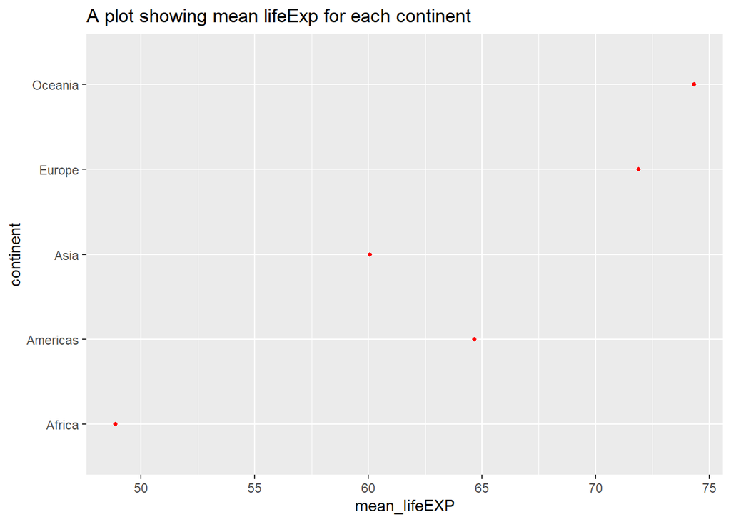

```r
p %>%
  ggplot(aes(x=mean, y= continent))+
  geom_point(size =1, color="red")+
  labs(title = "A plot showing mean lifeExp for each continent",
       x = "mean_lifeEXP")
```